# Is every country song the same?

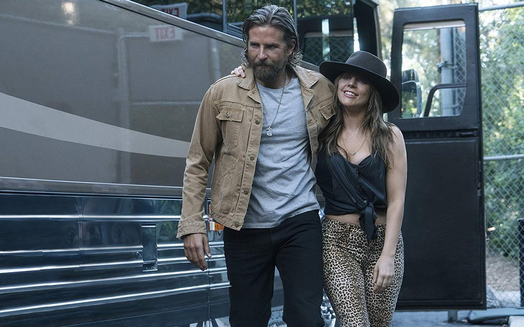

This notebook was prepared with the following environmental settings.

```r
print(R.version)
```

```
##                _
## platform       x86_64-apple-darwin15.6.0
## arch           x86_64
## os             darwin15.6.0
## system         x86_64, darwin15.6.0
## status
## major          3
## minor          6.1
## year           2019
## month          07
## day            05
## svn rev        76782
## language       R
## version.string R version 3.6.1 (2019-07-05)
## nickname       Action of the Toes
```

# Introduction:

I grew up on Long Island, an hour east of here. My parents grew up on Long Island too, and although they love folk singers from their youth like Neil Young and Bob Dylan, none of us have ever cared for the country music you’d hear on the radio nowadays. In my view, it’s because country songs are all about one of three things: livin’ right, drinking after a breakup, or unrequited love. And that repetition gets boring!

However, we’re all data scientists, and I know that letting an assumption like this stand without evidence would be a mistake. So, I set out to determine whether the sentiments in country music *are* actually the same more of the time than for other genres.

## Step One: Cleaning the lyrics data

To clean the lyrics data provided, I used the provided Text_Processing.Rmd app.

## Step Two: Major sentiments of different genres

To start, I’ve created an overview of the sentiments of different genres via word cloud. However, these aren’t typical word clouds: I started by taking data for all the lyrics in the data set together. Then, to generate the word cloud for each genre, I focused on the words that differ the most from this generic word cloud. This made a series of word clouds that more accurately explain the *differences* between the genres.

### Preparations for visualization

The lyric word counts are made into proportions. Then the average proportions are subtracted, leaving the words most overrepresented in a given genre.

### Displaying Word Clouds

Here’s the word cloud for all genres. Notice how love is the biggest word, but it’s balanced out by “time,” “your,” and “baby,” to name a few.

[interactive chart not shown]

Now, here’s the word cloud for the words overrepresented in country music compared to the average song. You’ll notice “love” is more dominant, along with “heart.” We can also make out words we generally associate with country music, like “lord,” “cowboy,” “daddy,” and “guitar.”

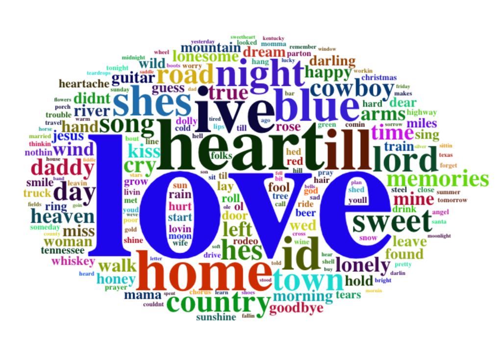

Finally, here’s what the word cloud of words overrepresented in metal songs looks like. I don’t think I have to interpret this one for you.

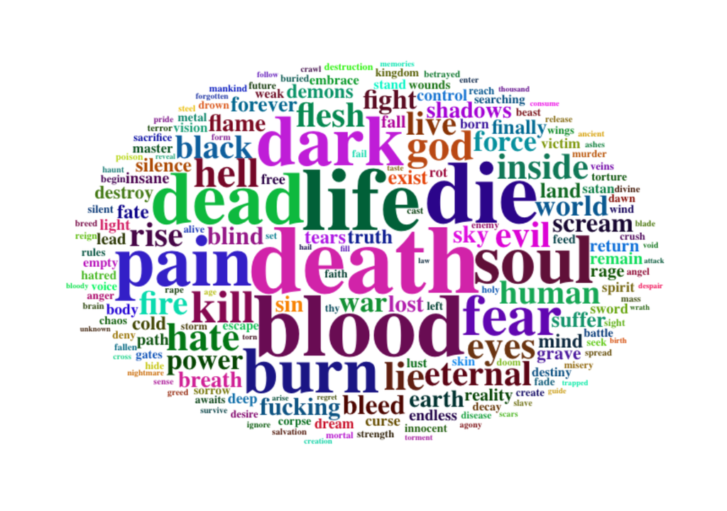

As you can see, the word cloud for country music mostly resembles other genreswhile the word cloud for metal music has much different language. This is our first hint that country music doesn’t differ much from the other genres. But what about our original question: are all country songs the same?

## Within the country genre

Using a strategy similar to the above, let’s look at the way country songs have changed over time. For each decade from the ’70s to the ’2010s, let’s figure out which words are overrepresented compared to the average of all the country songs from each decade.

## 1970’s Country Music Word Cloud

[interactive chart not shown]

|  | word | percent |
| --- | --- | --- |
| 1 | jack | 0.021044544 |
| 2 | rock | 0.020701442 |
| 3 | ah | 0.010035437 |
| 4 | alive | 0.008648618 |
| 5 | shes | 0.008184473 |
| 6 | burnin | 0.007968538 |
| 7 | rise | 0.007112602 |
| 8 | drink | 0.006812553 |
| 9 | blood | 0.006743832 |
| 10 | roll | 0.006149530 |

## 1990’s Country Music Word Cloud

[interactive chart not shown]

|  | word | percent |
| --- | --- | --- |
| 1 | youre | 0.006076970 |
| 2 | life | 0.003703398 |
| 3 | fm | 0.003677575 |
| 4 | youll | 0.003518644 |
| 5 | bm | 0.003458077 |
| 6 | fall | 0.003394606 |
| 7 | lie | 0.003275097 |
| 8 | kill | 0.003234050 |
| 9 | inside | 0.003106076 |
| 10 | bb | 0.002772340 |

## 2010’s Country Music Word Cloud

[interactive chart not shown]

|  | word | percent |
| --- | --- | --- |
| 1 | youre | 0.001934468 |
| 2 | life | 0.001891450 |
| 3 | inside | 0.001443340 |
| 4 | coming | 0.001431269 |
| 5 | world | 0.001305192 |
| 6 | chorus | 0.001296529 |
| 7 | fear | 0.001288900 |
| 8 | waiting | 0.001268759 |
| 9 | words | 0.001195131 |
| 10 | fall | 0.001185797 |

## Sentiment analysis

Let’s see if we can detect differences in the sentiments of the songs between the decades.

First up, an overall sentiment analysis of country songs.

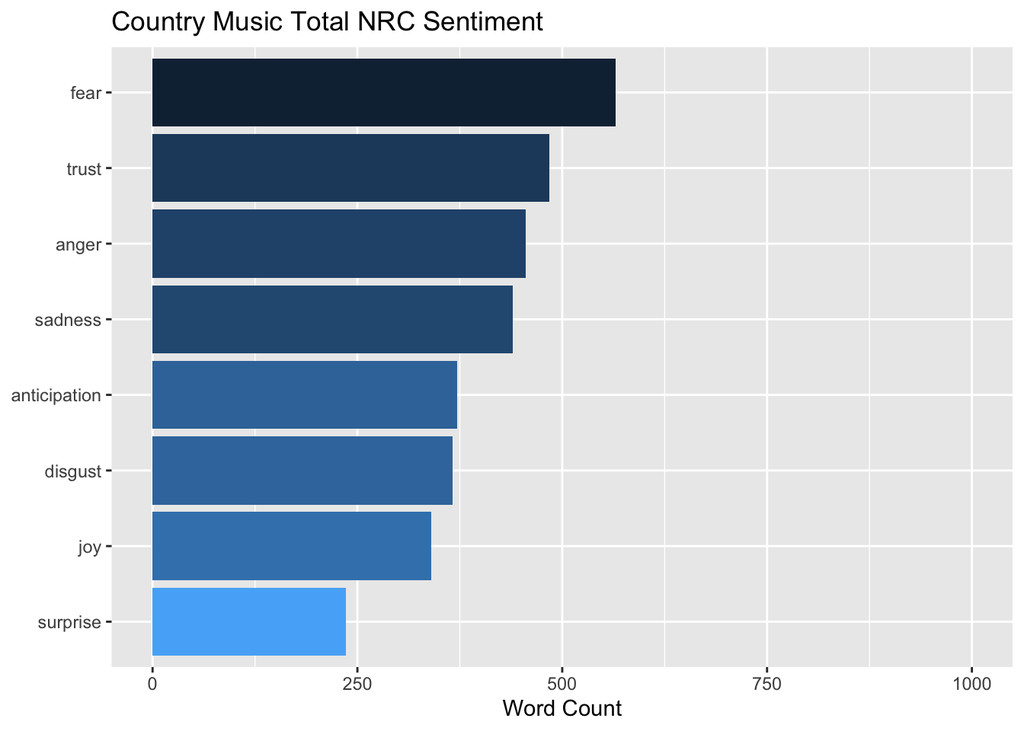

Next, let’s see if it looks different from Metal songs, like it did in the word cloud earlier

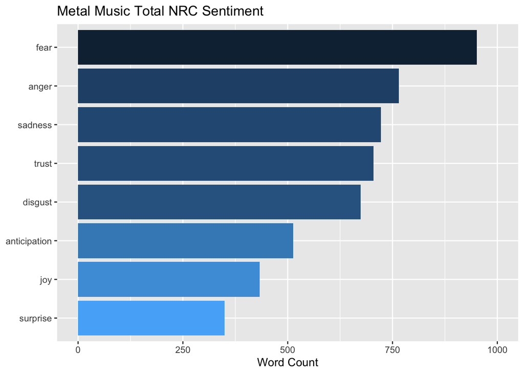

These charts aren’t so different, though a few of the emotions switch places. Let’s see if we can find sentimental differences between the ’70s, ’90s, and 2010s in Country music.

[interactive chart not shown]

Let’s join these together into a radar chart

[interactive chart not shown]